# Coursera - Reproducible Research Course Project 1

Charl Arthur Henry Cowley

May 18, 2017

## Loading and preprocessing the data

1.Load the data using read.csv

```r
activity <- read.csv("C:activity.csv",header = TRUE)
activity$date <- as.POSIXct(activity$date)
class(activity$date)
```

```
## [1] "POSIXct" "POSIXt"
```

```r
daymean <- aggregate(steps ~ date, data = activity, sum)
```

If you do not understand the difference between a histogram and a barplot, research the difference between them. 2. Make a histogram of the total number of steps taken each day

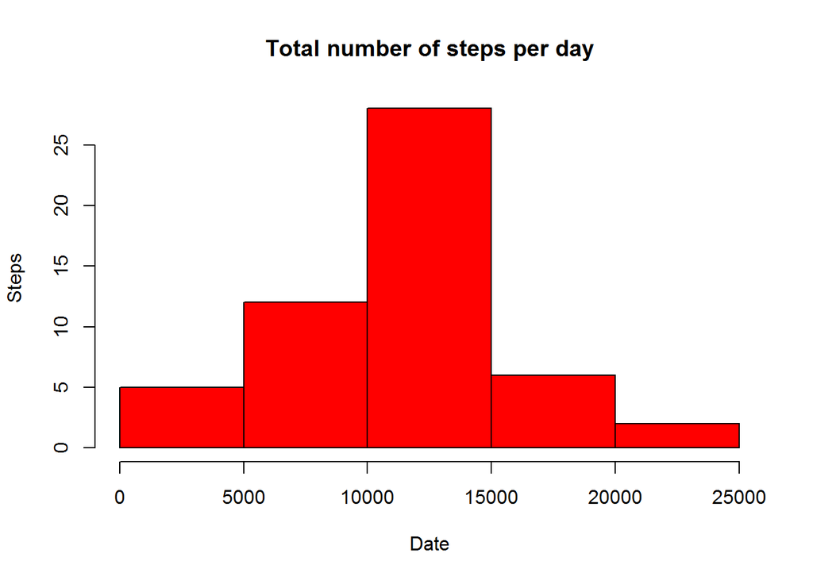

```r
par(mfrow=c(1,1))
hist(daymean$steps,col="red",xlab="Date",ylab="Steps",main="Total number of steps per day")
```

3. Calculate and report the mean and median of the total number of steps taken per day

```r
h <- summary(daymean$steps)
h[c("Median","Mean")]
```

```
## Median   Mean
##  10760  10770
```

## What is the average daily activity pattern?

2. Make a time series plot (i.e. type = “l”) of the 5-minute interval (x-axis) and the average number of steps taken, averaged across all days (y-axis)

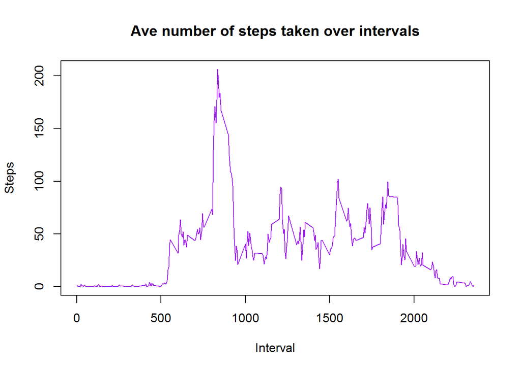

```r
intmean <- aggregate(steps~interval,data=activity,mean)
plot(intmean$interval,intmean$steps,type="l",xlab="Interval",col="purple",ylab="Steps",main="Ave number of steps taken over intervals")
```

3. Which 5-minute interval, on average across all the days in the dataset, contains the maximum number of steps?

```r
intmean[which(intmean$steps == max(intmean$steps)),]
```

```
##     interval    steps
## 104      835 206.1698
```

## Imputing missing values

1. Calculate and report the total number of missing values in the dataset (i.e. the total number of rows with NAs)

```r
summary(is.na(activity$steps))
```

```
##    Mode   FALSE    TRUE    NA's
## logical   15264    2304       0
```

```r
summary(activity$steps)
```

```
##    Min. 1st Qu.  Median    Mean 3rd Qu.    Max.    NA's
##    0.00    0.00    0.00   37.38   12.00  806.00    2304
```

2. Devise a strategy for filling in all of the missing values in the dataset. The strategy does not need to be sophisticated.

I will impute the NAs with the mean of the interval it falls in.

3. Create a new dataset that is equal to the original dataset but with the missing data filled in.

```r
library(dplyr)
df1 <- activity %>%
        group_by(interval) %>%
        summarise(avg=mean(steps,na.rm=TRUE)) %>%
        merge(activity, ., all.x=TRUE) %>%
        mutate(steps=ifelse(is.na(steps)==TRUE,avg, steps))%>%
        select(-avg)
```

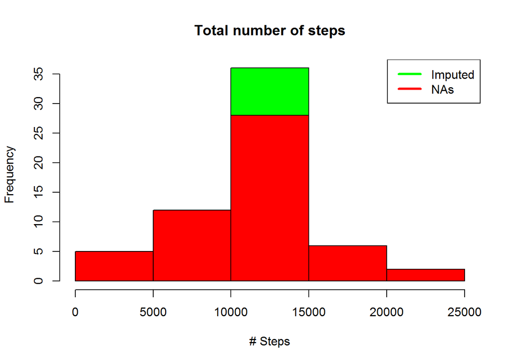

```r
daymean2 <- aggregate(steps ~ date, data = df1, sum)
par(mfrow=c(1,1))
hist(daymean2$steps,col="green",xlab="# Steps",ylab="Frequency",main="Total number of steps")
hist(daymean$steps,col="red",xlab="# Steps",ylab="Frequency",add=TRUE)
legend("topright",c("Imputed","NAs"),col=c("green","red"),lwd=3)
```

## Are there differences in activity patterns between weekdays and weekends?

```r
weekend <- c("Friday","Saturday","Sunday")
activity$typeday <- factor((weekdays(activity$date) %in% weekend),levels=c(FALSE,TRUE),labels=c("Weekday","Weekend"))
```

2. Make a panel plot containing a time series plot (i.e. type = “l”) of the 5-minute interval (x-axis) and the average number of steps taken, averaged across all weekday days or weekend days (y-axis).

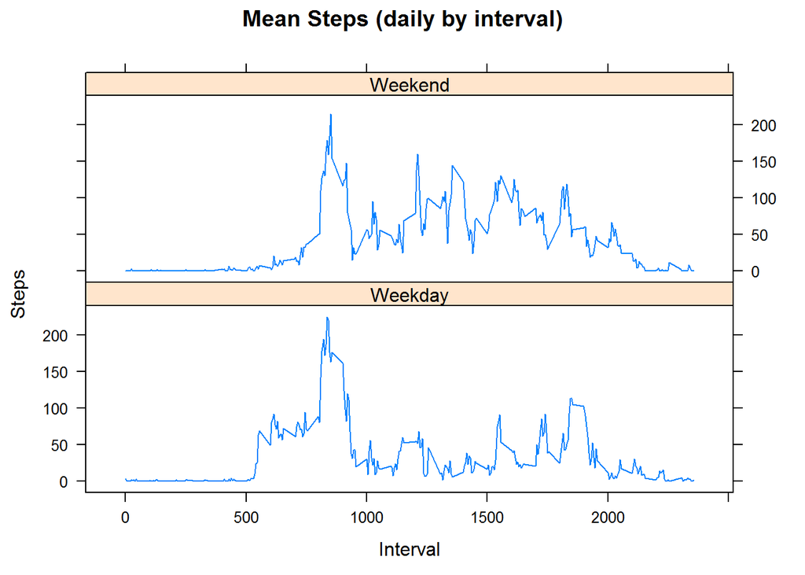

```r
library(lattice)
step_int <- aggregate(steps ~ interval + typeday,data = activity, mean)

xyplot(step_int$steps ~ step_int$interval | step_int$typeday, main = "Mean Steps (daily by interval)",xlab="Interval",ylab="Steps",layout=c(1,2),type="l")
```

**THE END**